# Macrofaunal Total Biomass

Chih-Lin Wei

2023-03-03

```r
library(bbbs)
library(ggplot2)
library(plyr)
library(doBy)
library(readxl)
library(knitr)
library(nlme)

large <- theme(legend.title = element_text(size=20),
        legend.text = element_text(size=20),
        axis.title = element_text(size=20),
        axis.text = element_text(size=20))

# dark theme for ggplot
dark <- theme(plot.background = element_rect(colour = 'NA', fill = 'gray10'),
        panel.background = element_rect(colour = 'NA', fill = 'transparent'),
        legend.background = element_rect(colour = 'NA', fill = 'transparent'),
        legend.title = element_text(colour = 'white', size=20),
        legend.text = element_text(colour = 'white', size=20),
        axis.title = element_text(colour = 'white', size=20),
        axis.text = element_text(colour = 'white', size=20),
        axis.ticks = element_line(colour = 'white'),
        panel.border = element_rect(fill = 'NA', colour = 'white'),
        panel.grid.major = element_line(colour = 'gray30'),
        panel.grid.minor = element_line(colour = 'gray20'))

jet.colors <-colorRampPalette(c("#00007F", "blue", "#007FFF", "cyan",
                     "#7FFF7F", "yellow", "#FF7F00", "red", "#7F0000"))
```

# 1 Mean density

## 1.1 per cruise

```r
# Convert the numbers of polychaete specimen (with head) to abundance
pols <- subset(mac, Taxon=="Polychaeta" & (Condition=="FH" | Condition=="C" | Condition=="FHT"))
pola <- summaryBy(Size~Cruise+Station+Deployment+Tube+Taxon, data=pols, FUN=length, var.names="Abundance", keep.names = T)
pola <- cbind(pola[, 1:4], Section="0-15", pola[, 5:6], Comment="")

# Replace polycahete sorting abundance with correct abundance from size data
sort <- read_excel("../excel/GPSC_macro_sorting_2020.07.31.xlsx", sheet=2)
sort <- rbind(subset(sort, Taxon!="Polychaeta"), pola)
# Remove Cyclopoida and Calanoida
sort <- subset(sort, !(Taxon=="Cyclopoida"|Taxon=="Calanoida"))
# Total abundance by tube
abun <- summaryBy(Abundance~Cruise+Station+Deployment+Tube, data=as.data.frame(sort), FUN=sum, keep.names = TRUE)
depth <- read_excel("../excel/GPSC_macro_sorting_2020.07.31.xlsx", sheet=1)
abun <- cbind(depth[match(paste(abun$Cruise, abun$Station), paste(depth$Cruise, depth$Station)),], Abundance=abun$Abundance)


dat <- subset(abun, Cruise=="OR1_1096"|Cruise=="OR1_1102"|Cruise=="OR1_1114"|Cruise=="OR1_1126")
# Remove outlier samples with only 1 individuals
bad <- with(dat, Abundance <=1 | (Cruise=="OR1_1102" & Station == "GS4") )
dat <- subset(dat, !bad)

dat$Density <- dat$Abundance/dat$Area
dat.mean <- summaryBy(Density+Longitude+Latitude+Depth+Date~Habitat+Cruise+Station, data=dat, FUN=c(mean, sd, length))
dat.mean$Date.mean <- strftime(as.POSIXct(dat.mean$Date.mean, origin = "1970-01-01", tz = "Asia/Taipei"), format="%Y-%m-%d")
dat.mean$Density.se <- dat.mean$Density.sd/dat.mean$Density.length^0.5

out <- dat.mean[, c("Habitat", "Cruise", "Station", "Longitude.mean", "Latitude.mean", "Depth.mean", "Date.mean", "Density.length", "Density.mean", "Density.sd", "Density.se")]
names(out) <- c("Habitat", "Cruise", "Station", "Longitude", "Latitude", "Depth", "Date", "n", "Density", "sd", "se")

#out$Longitude <- round(out$Longitude, 4)
#out$Latitude <- round(out$Latitude, 4)
#out$Depth <- round(out$Depth, 0)
#out$Density <- round(out$Density, 0)
#out$sd <- round(out$sd, 1)
#out$se <- round(out$se, 1)
kable(out, align="c", caption="OR1_1102 GS4, OR1_1126 GC2, and OR1_1126 GC3 Tube 2 had very low abundance and only single replication. They are removed as outliers before plotting")
```

OR1_1102 GS4, OR1_1126 GC2, and OR1_1126 GC3 Tube 2 had very low abundance and only single replication. They are removed as outliers before plotting

| Habitat | Cruise | Station | Longitude | Latitude | Depth | Date | n | Density | sd | se |
| --- | --- | --- | --- | --- | --- | --- | --- | --- | --- | --- |
| Canyon | OR1_1096 | GC1 | 120.4170 | 22.41700 | 222.00 | 2014-11-28 | 3 | 1928.4597 | 477.1700 | 275.49424 |
| Canyon | OR1_1096 | GC2 | 120.3418 | 22.40783 | 462.00 | 2014-11-26 | 3 | 4407.9078 | 2353.8238 | 1358.98080 |
| Canyon | OR1_1096 | GC3 | 120.2664 | 22.34998 | 655.00 | 2014-11-27 | 3 | 2571.2795 | 1301.9350 | 751.67250 |
| Canyon | OR1_1102 | GC1 | 120.4114 | 22.41732 | 323.00 | 2015-04-06 | 1 | 550.9885 | NA | NA |
| Canyon | OR1_1102 | GC2 | 120.3327 | 22.40044 | 482.00 | 2015-04-06 | 3 | 918.3141 | 318.1133 | 183.66282 |
| Canyon | OR1_1102 | GC3 | 120.2665 | 22.34825 | 653.00 | 2015-04-06 | 3 | 2387.6167 | 1517.3039 | 876.01584 |
| Canyon | OR1_1102 | GC4 | 120.1921 | 22.29808 | 1065.20 | 2015-04-06 | 3 | 6428.1989 | 3542.3603 | 2045.18266 |
| Canyon | OR1_1114 | GC1 | 120.4113 | 22.41718 | 320.00 | 2015-08-04 | 5 | 669.8222 | 556.2570 | 248.76571 |
| Canyon | OR1_1114 | GC2 | 120.3348 | 22.40067 | 478.00 | 2015-08-04 | 4 | 3291.3676 | 1477.4461 | 738.72305 |
| Canyon | OR1_1114 | GC3 | 120.2668 | 22.35002 | 653.00 | 2015-08-04 | 4 | 4850.4364 | 1791.5936 | 895.79679 |
| Canyon | OR1_1114 | GC4 | 120.1928 | 22.29800 | 1051.00 | 2015-08-05 | 5 | 2286.6343 | 1644.2142 | 735.31496 |
| Canyon | OR1_1126 | GC1 | 120.4112 | 22.41750 | 318.00 | 2015-11-21 | 5 | 369.5571 | 150.5761 | 67.33967 |
| Canyon | OR1_1126 | GC3 | 120.2663 | 22.34917 | 655.00 | 2015-11-20 | 2 | 808.4061 | 163.3227 | 115.48658 |
| Canyon | OR1_1126 | GC4 | 120.1930 | 22.29800 | 1065.00 | 2015-11-20 | 4 | 2223.1167 | 1280.3742 | 640.18710 |
| Slope | OR1_1096 | GS1 | 120.4006 | 22.23493 | 270.00 | 2014-11-27 | 3 | 4867.0648 | 3400.2433 | 1963.13137 |
| Slope | OR1_1096 | GS2 | 120.3332 | 22.21660 | 465.00 | 2014-11-28 | 3 | 7346.5130 | 1590.5667 | 918.31412 |
| Slope | OR1_1096 | GS3 | 120.2997 | 22.18372 | 692.00 | 2014-11-28 | 3 | 2938.6052 | 1043.0043 | 602.17884 |
| Slope | OR1_1102 | GS1 | 120.4006 | 22.23289 | 278.67 | 2015-04-07 | 3 | 10468.7810 | 2754.9424 | 1590.56672 |
| Slope | OR1_1102 | GS2 | 120.3298 | 22.21676 | 463.54 | 2015-04-07 | 3 | 9825.9611 | 1935.0079 | 1117.17735 |
| Slope | OR1_1102 | GS3 | 120.3001 | 22.18311 | 682.00 | 2015-04-07 | 4 | 2961.5630 | 1673.8778 | 836.93892 |
| Slope | OR1_1114 | GS1 | 120.3998 | 22.23217 | 279.00 | 2015-08-05 | 4 | 6986.9382 | 2839.0288 | 1419.51441 |
| Slope | OR1_1114 | GS2 | 120.3297 | 22.21717 | 462.00 | 2015-08-05 | 5 | 6074.5942 | 4812.8955 | 2152.39231 |
| Slope | OR1_1114 | GS3 | 120.2998 | 22.18333 | 690.00 | 2015-08-05 | 4 | 5139.1529 | 2134.6803 | 1067.34013 |
| Slope | OR1_1114 | GS4 | 120.2304 | 22.14008 | 848.00 | 2015-08-05 | 4 | 7910.8309 | 876.9886 | 438.49430 |
| Slope | OR1_1126 | GS1 | 120.3995 | 22.23290 | 277.00 | 2015-11-19 | 4 | 5774.3291 | 2229.4195 | 1114.70977 |
| Slope | OR1_1126 | GS2 | 120.3298 | 22.21667 | 463.00 | 2015-11-19 | 4 | 6958.0666 | 1731.9779 | 865.98895 |
| Slope | OR1_1126 | GS3 | 120.3002 | 22.18293 | 690.00 | 2015-11-19 | 4 | 4099.7737 | 745.4627 | 372.73134 |
| Slope | OR1_1126 | GS4 | 120.2293 | 22.14000 | 848.00 | 2015-11-20 | 4 | 6351.7620 | 3113.1436 | 1556.57178 |

### 1.1.1 Linear regression with depth

```r
splitBy(~Habitat, out) %>% lapply(FUN=function(x)lm(log10(Density)~Depth, data=x) %>% summary)
```

```
## $Canyon
##
## Call:
## lm(formula = log10(Density) ~ Depth, data = x)
##
## Residuals:
##      Min       1Q   Median       3Q      Max
## -0.47837 -0.22620 -0.05215  0.28863  0.49627
##
## Coefficients:
##              Estimate Std. Error t value Pr(>|t|)
## (Intercept) 2.8209938  0.2147158  13.138 1.75e-08 ***
## Depth       0.0007077  0.0003249   2.179     0.05 .
## ---
## Signif. codes:  0 '***' 0.001 '**' 0.01 '*' 0.05 '.' 0.1 ' ' 1
##
## Residual standard error: 0.3365 on 12 degrees of freedom
## Multiple R-squared:  0.2834, Adjusted R-squared:  0.2237
## F-statistic: 4.746 on 1 and 12 DF,  p-value: 0.05003
##
##
## $Slope
##
## Call:
## lm(formula = log10(Density) ~ Depth, data = x)
##
## Residuals:
##       Min        1Q    Median        3Q       Max
## -0.254873 -0.102599  0.000684  0.112581  0.218976
##
## Coefficients:
##               Estimate Std. Error t value Pr(>|t|)
## (Intercept)  3.9171684  0.1216083  32.211 5.06e-13 ***
## Depth       -0.0002806  0.0002145  -1.308    0.215
## ---
## Signif. codes:  0 '***' 0.001 '**' 0.01 '*' 0.05 '.' 0.1 ' ' 1
##
## Residual standard error: 0.1631 on 12 degrees of freedom
## Multiple R-squared:  0.1247, Adjusted R-squared:  0.05181
## F-statistic:  1.71 on 1 and 12 DF,  p-value: 0.2154
```

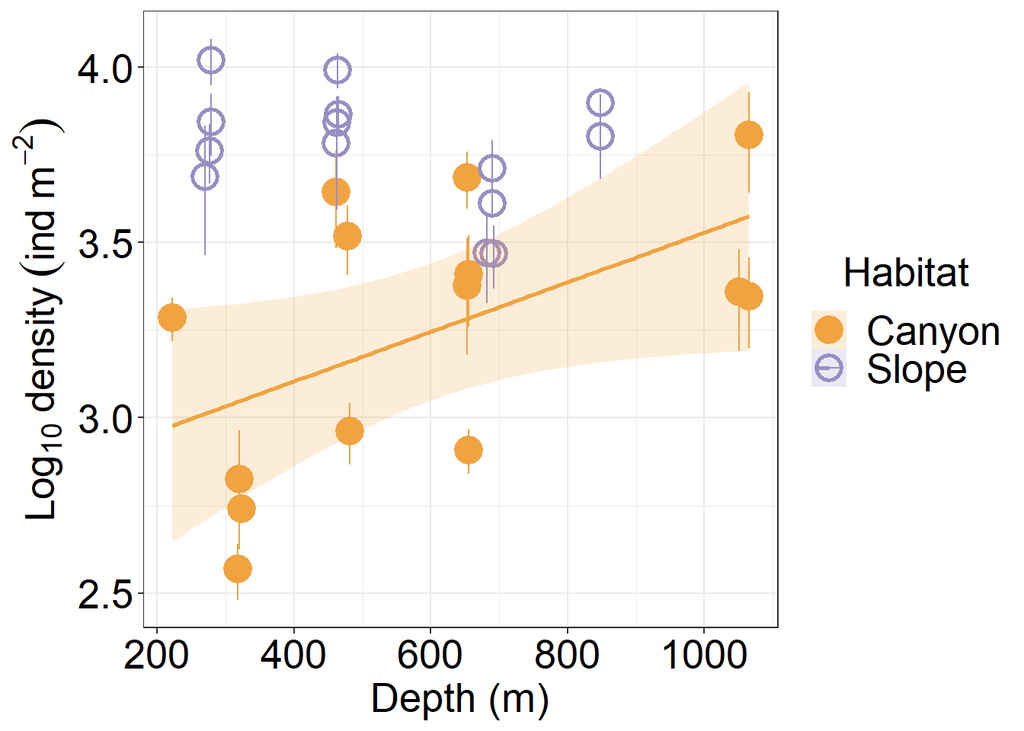

```r
ggplot(data=out,
       aes(x=Depth, y=log10(Density),
           ymin=log10(Density-se), ymax=log10(Density+se),
           colour=Habitat, fill=Habitat, linetype=Habitat,
           shape=Habitat))+
  geom_point(size=5, stroke=1.5, position = "dodge")+
  stat_smooth(data=subset(out, Habitat=="Canyon"), method="lm", formula=y~x, alpha=0.2)+
  geom_errorbar(linetype=1, position = "dodge")+
  scale_colour_manual(values=c("#f1a340", "#998ec3"))+
  scale_fill_manual(values=c("#f1a340", "#998ec3"))+
  scale_linetype_manual(values=c(1,2))+
  scale_shape_manual(values=c(19,1))+
  labs(x="Depth (m)", y=expression(Log[10]~density~(ind~m^-2)))+
  #scale_y_log10()+
  theme_bw() %+replace% large #%+replace% dark
```

### 1.1.2 Generalized Least Squares (GLS) modeling

Macrofauna density of each sample were averaged by station (i.e., average of three cores) before further statistical tests. We used Generalized Least Squares (GLS) modeling to examine the effects of habitat (canyon vs. slope), depth, and sampling time on the mean macrofauna density.

#### 1.1.2.1 Main test

```r
f <- gls(log10(Density) ~ Habitat+Depth+Cruise+Habitat:Depth+Habitat:Cruise+Depth:Cruise, data=out, method = "REML")
kable(summary(f)$tTable)
```

|  | Value | Std.Error | t-value | p-value |
| --- | --- | --- | --- | --- |
| (Intercept) | 3.2294048 | 0.2867977 | 11.2602178 | 0.0000000 |
| HabitatSlope | 0.7824576 | 0.2619482 | 2.9870703 | 0.0092120 |
| Depth | 0.0004865 | 0.0005698 | 0.8537937 | 0.4066480 |
| CruiseOR1_1102 | -0.7047889 | 0.3786001 | -1.8615655 | 0.0823752 |
| CruiseOR1_1114 | -0.3714049 | 0.3615708 | -1.0271982 | 0.3206076 |
| CruiseOR1_1126 | -1.0181232 | 0.3806393 | -2.6747714 | 0.0173121 |
| HabitatSlope:Depth | -0.0011971 | 0.0003950 | -3.0309984 | 0.0084236 |
| HabitatSlope:CruiseOR1_1102 | 0.5639130 | 0.2642382 | 2.1341081 | 0.0497493 |
| HabitatSlope:CruiseOR1_1114 | 0.4053413 | 0.2544667 | 1.5929049 | 0.1320315 |
| HabitatSlope:CruiseOR1_1126 | 0.8313936 | 0.2667472 | 3.1167845 | 0.0070706 |
| Depth:CruiseOR1_1102 | 0.0006200 | 0.0006601 | 0.9392434 | 0.3624853 |
| Depth:CruiseOR1_1114 | 0.0002954 | 0.0006309 | 0.4683024 | 0.6463009 |
| Depth:CruiseOR1_1126 | 0.0005873 | 0.0006335 | 0.9272005 | 0.3685019 |

```r
kable(anova(f))
```

|  | numDF | F-value | p-value |
| --- | --- | --- | --- |
| (Intercept) | 1 | 6530.207078 | 0.0000000 |
| Habitat | 1 | 36.297927 | 0.0000233 |
| Depth | 1 | 4.094719 | 0.0612120 |
| Cruise | 3 | 1.668214 | 0.2163067 |
| Habitat:Depth | 1 | 7.182865 | 0.0171288 |
| Habitat:Cruise | 3 | 3.440517 | 0.0440391 |
| Depth:Cruise | 3 | 0.424496 | 0.7382523 |

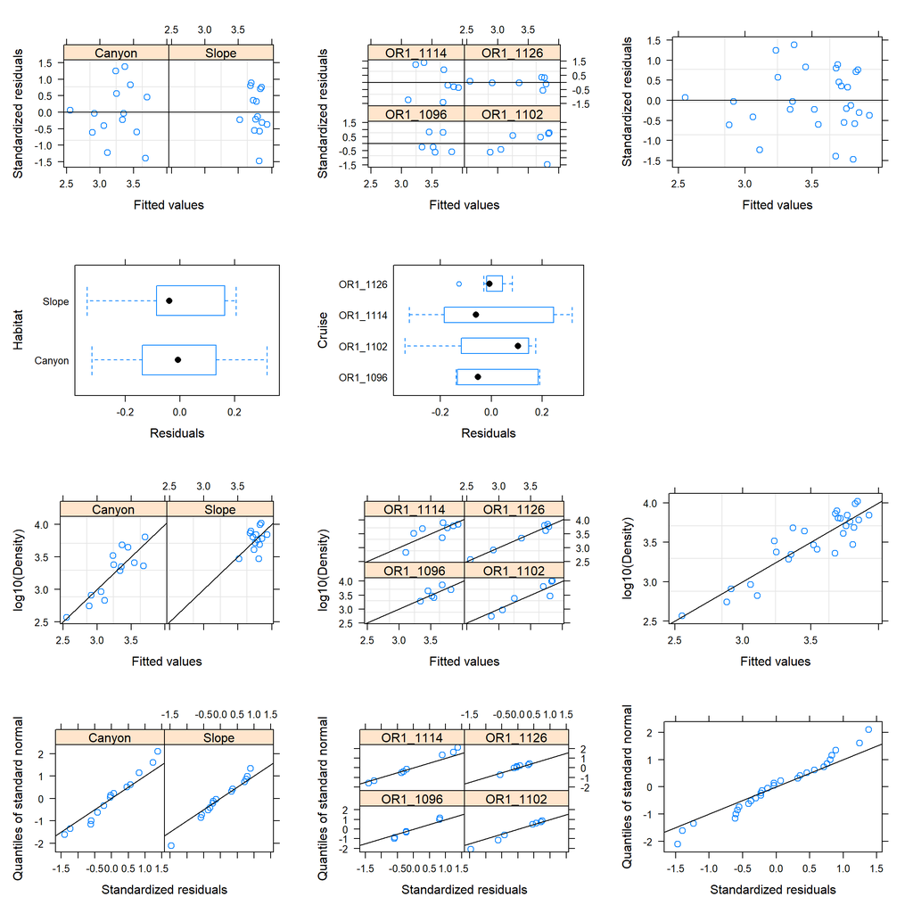

```r
# Function to plot dianotics plot
dianostic_plot <-
  function(f, y){
    # standardized residuals versus fitted values
    a1 <- plot(f, resid(., type = "p") ~ fitted(.) | Habitat, abline = 0)
    a2 <- plot(f, resid(., type = "p") ~ fitted(.) | Cruise, abline = 0)
    a3 <- plot(f, resid(., type = "p") ~ fitted(.), abline = 0)
    # box-plots of residuals
    b1<-plot(f, Habitat ~ resid(.))
    b2 <- plot(f, Cruise ~ resid(.))
    # observed versus fitted values
    c1<-plot(f, paste(paste(y, "fitted(.)", sep="~"), "Habitat", sep="|") %>% formula, abline = c(0,1))
    c2<-plot(f, paste(paste(y, "fitted(.)", sep="~"), "Cruise", sep="|") %>% formula, abline = c(0,1))
    c3<-plot(f, paste(y, "fitted(.)", sep="~") %>% formula, abline = c(0,1))
    # QQ plot
    d1<-qqnorm(f, ~ resid(., type = "p") | Habitat, abline = c(0,1))
    d2<-qqnorm(f, ~ resid(., type = "p") | Cruise, abline = c(0,1))
    d3<-qqnorm(f, ~ resid(., type = "p"), abline = c(0,1))

    print(a1, split=c(1,1,3,4), more=TRUE)
    print(a2, split=c(2,1,3,4), more=TRUE)
    print(a3, split=c(3,1,3,4), more=TRUE)
    print(b1, split=c(1,2,3,4), more=TRUE)
    print(b2, split=c(2,2,3,4), more=TRUE)
    #
    print(c1, split=c(1,3,3,4), more=TRUE)
    print(c2, split=c(2,3,3,4), more=TRUE)
    print(c3, split=c(3,3,3,4), more=TRUE)
    print(d1, split=c(1,4,3,4), more=TRUE)
    print(d2, split=c(2,4,3,4), more=TRUE)
    print(d3, split=c(3,4,3,4))
    }

dianostic_plot(f, y = "log10(Density)")
```

#### 1.1.2.2 Pairwise tests

```r
# In canyon
f <- gls(log10(Density) ~ Depth+Cruise+Depth:Cruise, data=subset(out, Habitat == "Canyon"), method = "REML")
kable(summary(f)$tTable)
```

|  | Value | Std.Error | t-value | p-value |
| --- | --- | --- | --- | --- |
| (Intercept) | 3.2962148 | 0.4127749 | 7.9855016 | 0.0002055 |
| Depth | 0.0003368 | 0.0008596 | 0.3917846 | 0.7087541 |
| CruiseOR1_1102 | -0.9899648 | 0.5274222 | -1.8769873 | 0.1096119 |
| CruiseOR1_1114 | -0.2621119 | 0.5285940 | -0.4958663 | 0.6376261 |
| CruiseOR1_1126 | -1.0648330 | 0.5551807 | -1.9179935 | 0.1035538 |
| Depth:CruiseOR1_1102 | 0.0011158 | 0.0009829 | 1.1352109 | 0.2995914 |
| Depth:CruiseOR1_1114 | 0.0001636 | 0.0009865 | 0.1658222 | 0.8737433 |
| Depth:CruiseOR1_1126 | 0.0007074 | 0.0009937 | 0.7119517 | 0.5032241 |

```r
kable(anova(f))
```

|  | numDF | F-value | p-value |
| --- | --- | --- | --- |
| (Intercept) | 1 | 2120.853780 | 0.0000000 |
| Depth | 1 | 7.728992 | 0.0319925 |
| Cruise | 3 | 3.674922 | 0.0820447 |
| Depth:Cruise | 3 | 0.839265 | 0.5199678 |

```r
# On slope
f <- gls(log10(Density) ~ Depth+Cruise+Depth:Cruise, data=subset(out, Habitat == "Slope"), method = "REML")
kable(summary(f)$tTable)
```

|  | Value | Std.Error | t-value | p-value |
| --- | --- | --- | --- | --- |
| (Intercept) | 3.9367508 | 0.2530219 | 15.5589320 | 0.0000045 |
| Depth | -0.0005527 | 0.0005001 | -1.1053025 | 0.3113683 |
| CruiseOR1_1102 | 0.5512347 | 0.3648747 | 1.5107507 | 0.1815995 |
| CruiseOR1_1114 | -0.1442313 | 0.3288082 | -0.4386487 | 0.6762700 |
| CruiseOR1_1126 | -0.1365746 | 0.3284617 | -0.4158008 | 0.6920176 |
| Depth:CruiseOR1_1102 | -0.0008376 | 0.0007237 | -1.1574074 | 0.2910958 |
| Depth:CruiseOR1_1114 | 0.0005821 | 0.0006072 | 0.9585558 | 0.3747983 |
| Depth:CruiseOR1_1126 | 0.0004733 | 0.0006067 | 0.7799985 | 0.4650390 |

```r
kable(anova(f))
```

|  | numDF | F-value | p-value |
| --- | --- | --- | --- |
| (Intercept) | 1 | 8912.5674883 | 0.0000000 |
| Depth | 1 | 2.0404998 | 0.2030818 |
| Cruise | 3 | 0.7985466 | 0.5382164 |
| Depth:Cruise | 3 | 1.9735691 | 0.2194309 |

```r
# OR1 1096
f <- gls(log10(Density) ~ Habitat+Depth+Habitat:Depth, data=subset(out, Cruise=="OR1_1096"), method = "REML")
kable(summary(f)$tTable)
```

|  | Value | Std.Error | t-value | p-value |
| --- | --- | --- | --- | --- |
| (Intercept) | 3.2962148 | 0.3636562 | 9.0640972 | 0.0119539 |
| HabitatSlope | 0.6405360 | 0.5358452 | 1.1953750 | 0.3544567 |
| Depth | 0.0003368 | 0.0007573 | 0.4447027 | 0.7000288 |
| HabitatSlope:Depth | -0.0008895 | 0.0010856 | -0.8193745 | 0.4986800 |

```r
kable(anova(f))
```

|  | numDF | F-value | p-value |
| --- | --- | --- | --- |
| (Intercept) | 1 | 1408.9482941 | 0.0007090 |
| Habitat | 1 | 1.4357753 | 0.3535561 |
| Depth | 1 | 0.0313624 | 0.8757458 |
| Habitat:Depth | 1 | 0.6713746 | 0.4986800 |

```r
# OR1 1102
f <- gls(log10(Density) ~ Habitat+Depth+Habitat:Depth, data=subset(out, Cruise=="OR1_1102"), method = "REML")
kable(summary(f)$tTable)
```

|  | Value | Std.Error | t-value | p-value |
| --- | --- | --- | --- | --- |
| (Intercept) | 2.3062501 | 0.1664483 | 13.855657 | 0.0008138 |
| HabitatSlope | 2.1817355 | 0.2882273 | 7.569495 | 0.0047823 |
| Depth | 0.0014526 | 0.0002417 | 6.011053 | 0.0092248 |
| HabitatSlope:Depth | -0.0028430 | 0.0005269 | -5.395464 | 0.0124774 |

```r
kable(anova(f))
```

|  | numDF | F-value | p-value |
| --- | --- | --- | --- |
| (Intercept) | 1 | 4748.25546 | 0.0000067 |
| Habitat | 1 | 35.14989 | 0.0095896 |
| Depth | 1 | 15.83886 | 0.0283817 |
| Habitat:Depth | 1 | 29.11103 | 0.0124774 |

```r
# OR1 1114
f <- gls(log10(Density) ~ Habitat+Depth+Habitat:Depth, data=subset(out, Cruise=="OR1_1114"), method = "REML")
kable(summary(f)$tTable)
```

|  | Value | Std.Error | t-value | p-value |
| --- | --- | --- | --- | --- |
| (Intercept) | 3.0341029 | 0.3758567 | 8.0724989 | 0.0012792 |
| HabitatSlope | 0.7584167 | 0.5651134 | 1.3420610 | 0.2506909 |
| Depth | 0.0005004 | 0.0005509 | 0.9082558 | 0.4151157 |
| HabitatSlope:Depth | -0.0004710 | 0.0008847 | -0.5324169 | 0.6226382 |

```r
kable(anova(f))
```

|  | numDF | F-value | p-value |
| --- | --- | --- | --- |
| (Intercept) | 1 | 1136.7328378 | 0.0000046 |
| Habitat | 1 | 4.7407641 | 0.0950278 |
| Depth | 1 | 0.5432558 | 0.5019817 |
| Habitat:Depth | 1 | 0.2834678 | 0.6226382 |

```r
# OR1 1126
f <- gls(log10(Density) ~ Habitat+Depth+Habitat:Depth, data=subset(out, Cruise=="OR1_1126"), method = "REML")
kable(summary(f)$tTable)
```

|  | Value | Std.Error | t-value | p-value |
| --- | --- | --- | --- | --- |
| (Intercept) | 2.2313818 | 0.1387050 | 16.087252 | 0.0005224 |
| HabitatSlope | 1.5687943 | 0.1957634 | 8.013726 | 0.0040564 |
| Depth | 0.0010442 | 0.0001862 | 5.607462 | 0.0112087 |
| HabitatSlope:Depth | -0.0011237 | 0.0002933 | -3.830951 | 0.0313403 |

```r
kable(anova(f))
```

|  | numDF | F-value | p-value |
| --- | --- | --- | --- |
| (Intercept) | 1 | 8366.39555 | 0.0000029 |
| Habitat | 1 | 117.07108 | 0.0016889 |
| Depth | 1 | 16.89044 | 0.0260859 |
| Habitat:Depth | 1 | 14.67619 | 0.0313403 |

## 1.2 Per station

```r
dat.mean <- summaryBy(Density+Longitude+Latitude+Depth~Habitat+Station, data=out, FUN=c(mean, sd, length))
dat.mean$Density.se <- dat.mean$Density.sd/dat.mean$Density.length^0.5

out <- dat.mean[,c("Habitat", "Station", "Longitude.mean", "Latitude.mean", "Depth.mean", "Density.length", "Density.mean", "Density.sd", "Density.se")]
names(out) <- c("Habitat", "Station", "Longitude", "Latitude", "Depth","n", "Density", "sd", "se")

out$Longitude <- round(out$Longitude, 4)
out$Latitude <- round(out$Latitude, 4)
out$Depth <- round(out$Depth, 0)
out$Density <- round(out$Density, 0)
out$sd <- round(out$sd, 1)
out$sd <- round(out$se, 1)
kable(out, align="c")
```

| Habitat | Station | Longitude | Latitude | Depth | n | Density | sd | se |
| --- | --- | --- | --- | --- | --- | --- | --- | --- |
| Canyon | GC1 | 120.4127 | 22.4173 | 296 | 4 | 880 | 355.0 | 354.9933 |
| Canyon | GC2 | 120.3365 | 22.4030 | 474 | 3 | 2873 | 1028.9 | 1028.8966 |
| Canyon | GC3 | 120.2665 | 22.3494 | 654 | 4 | 2654 | 832.1 | 832.0833 |
| Canyon | GC4 | 120.1927 | 22.2980 | 1060 | 3 | 3646 | 1391.2 | 1391.2286 |
| Slope | GS1 | 120.4001 | 22.2332 | 276 | 4 | 7024 | 1227.5 | 1227.5292 |
| Slope | GS2 | 120.3306 | 22.2168 | 463 | 4 | 7551 | 803.6 | 803.5653 |
| Slope | GS3 | 120.3000 | 22.1833 | 688 | 4 | 3785 | 526.6 | 526.5647 |
| Slope | GS4 | 120.2299 | 22.1400 | 848 | 2 | 7131 | 779.5 | 779.5344 |

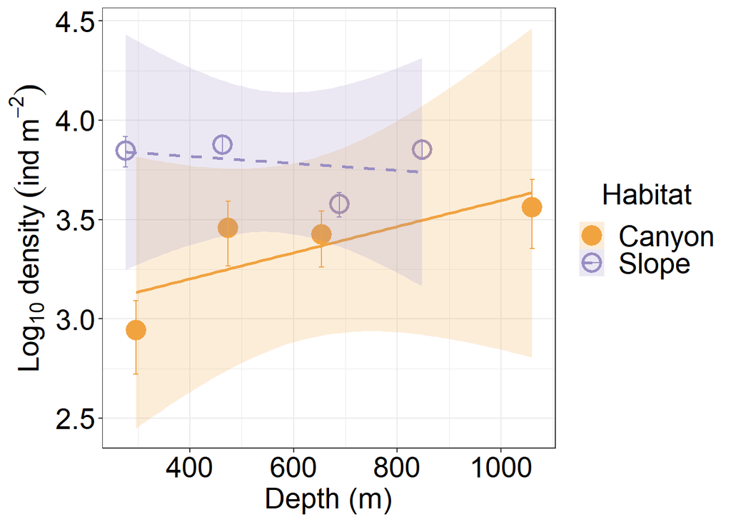

```r
ggplot(data=out,
       aes(x=Depth, y=log10(Density),
           ymin=log10(Density-se), ymax=log10(Density+se),
           colour=Habitat, fill=Habitat, linetype=Habitat, shape=Habitat))+
  geom_point(size=5, stroke=1.5, position = "dodge")+
  stat_smooth(method="lm", formula=y~x, alpha=0.2)+
  geom_errorbar(linetype=1, position = "dodge")+
  scale_colour_manual(values=c("#f1a340", "#998ec3"))+
  scale_fill_manual(values=c("#f1a340", "#998ec3"))+
  scale_linetype_manual(values=c(1,2))+
  scale_shape_manual(values=c(19,1))+
  labs(x="Depth (m)", y=expression(Log[10]~density~(ind~m^-2)))+
  theme_bw() %+replace% large #%+replace% dark
```

# 2 Mean biomass

## 2.1 Per cruise

```r
dat <- mac

dat <- subset(dat, Cruise=="OR1_1096"|Cruise=="OR1_1102"|Cruise=="OR1_1114"|Cruise=="OR1_1126")

dat.sum <- summaryBy(Wt+Area+Longitude+Latitude+Depth~Habitat+Cruise+Station+Deployment+Tube, data=dat, FUN=c(sum, mean))
dat.sum$Biomass <- dat.sum$Wt.sum/dat.sum$Area.mean

dat.mean <- summaryBy(Biomass+Longitude.mean+Latitude.mean+Depth.mean~Habitat+Cruise+Station, data=dat.sum, FUN=c(mean, sd, length))
dat.mean$Biomass.se <- dat.mean$Biomass.sd/dat.mean$Biomass.length^0.5

out <- dat.mean[, c("Habitat", "Cruise", "Station", "Longitude.mean.mean", "Latitude.mean.mean", "Depth.mean.mean", "Biomass.length", "Biomass.mean", "Biomass.sd", "Biomass.se")]
names(out) <- c("Habitat", "Cruise", "Station", "Longitude", "Latitude", "Depth", "n", "Biomass", "sd", "se")

#out$Longitude <- round(out$Longitude, 4)
#out$Latitude <- round(out$Latitude, 4)
#out$Depth <- round(out$Depth, 0)
#out$Biomass <- round(out$Biomass, 0)
#out$sd <- round(out$sd, 1)
#out$se <- round(out$se, 1)
kable(out, align="c")
```

| Habitat | Cruise | Station | Longitude | Latitude | Depth | n | Biomass | sd | se |
| --- | --- | --- | --- | --- | --- | --- | --- | --- | --- |
| Canyon | OR1_1096 | GC1 | 120.4170 | 22.41700 | 222.00 | 3 | 192.42601 | 149.767737 | 86.468443 |
| Canyon | OR1_1096 | GC2 | 120.3418 | 22.40783 | 462.00 | 3 | 227.74370 | 215.122381 | 124.200964 |
| Canyon | OR1_1096 | GC3 | 120.2664 | 22.34998 | 655.00 | 3 | 104.88734 | 54.412155 | 31.414872 |
| Canyon | OR1_1102 | GC1 | 120.4114 | 22.41732 | 323.00 | 1 | 60.32090 | NA | NA |
| Canyon | OR1_1102 | GC2 | 120.3327 | 22.40044 | 482.00 | 3 | 15.08324 | 8.972369 | 5.180200 |
| Canyon | OR1_1102 | GC3 | 120.2665 | 22.34825 | 653.00 | 3 | 500.75133 | 223.151654 | 128.836668 |
| Canyon | OR1_1102 | GC4 | 120.1921 | 22.29808 | 1065.20 | 3 | 148.44067 | 92.947068 | 53.663015 |
| Canyon | OR1_1114 | GC1 | 120.4113 | 22.41718 | 320.00 | 5 | 37.97044 | 41.928561 | 18.751022 |
| Canyon | OR1_1114 | GC2 | 120.3348 | 22.40067 | 478.00 | 4 | 115.03713 | 69.079361 | 34.539680 |
| Canyon | OR1_1114 | GC3 | 120.2668 | 22.35002 | 653.00 | 4 | 245.59325 | 206.651927 | 103.325963 |
| Canyon | OR1_1114 | GC4 | 120.1928 | 22.29800 | 1051.00 | 6 | 1516.38486 | 2896.851412 | 1182.634637 |
| Canyon | OR1_1126 | GC1 | 120.4112 | 22.41750 | 318.00 | 5 | 23.95163 | 16.211387 | 7.249953 |
| Canyon | OR1_1126 | GC3 | 120.2663 | 22.34917 | 655.00 | 2 | 1253.25169 | 1734.208344 | 1226.270480 |
| Canyon | OR1_1126 | GC4 | 120.1930 | 22.29800 | 1065.00 | 4 | 153.50120 | 115.249549 | 57.624775 |
| Slope | OR1_1096 | GS1 | 120.4006 | 22.23493 | 270.00 | 3 | 575.57287 | 449.293078 | 259.399480 |
| Slope | OR1_1096 | GS2 | 120.3332 | 22.21660 | 465.00 | 3 | 1238.97232 | 1000.573207 | 577.681211 |
| Slope | OR1_1096 | GS3 | 120.2997 | 22.18372 | 692.00 | 3 | 883.71112 | 625.751301 | 361.277682 |
| Slope | OR1_1102 | GS1 | 120.4006 | 22.23289 | 278.67 | 3 | 12337.94209 | 10751.838741 | 6207.576992 |
| Slope | OR1_1102 | GS2 | 120.3298 | 22.21676 | 463.54 | 3 | 4102.33842 | 6039.813624 | 3487.088022 |
| Slope | OR1_1102 | GS3 | 120.3001 | 22.18311 | 682.00 | 4 | 506.13699 | 587.597054 | 293.798527 |
| Slope | OR1_1114 | GS1 | 120.3998 | 22.23217 | 279.00 | 4 | 9012.91029 | 13999.527073 | 6999.763537 |
| Slope | OR1_1114 | GS2 | 120.3297 | 22.21717 | 462.00 | 5 | 4395.29584 | 6589.567260 | 2946.944067 |
| Slope | OR1_1114 | GS3 | 120.2998 | 22.18333 | 690.00 | 4 | 1370.55918 | 926.045539 | 463.022770 |
| Slope | OR1_1114 | GS4 | 120.2304 | 22.14008 | 848.00 | 4 | 2179.94466 | 1370.017621 | 685.008810 |
| Slope | OR1_1126 | GS1 | 120.3995 | 22.23290 | 277.00 | 4 | 2229.39423 | 816.976854 | 408.488427 |
| Slope | OR1_1126 | GS2 | 120.3298 | 22.21667 | 463.00 | 4 | 1460.73359 | 394.629892 | 197.314946 |
| Slope | OR1_1126 | GS3 | 120.3002 | 22.18293 | 690.00 | 4 | 1593.11901 | 389.909619 | 194.954810 |
| Slope | OR1_1126 | GS4 | 120.2293 | 22.14000 | 848.00 | 4 | 1160.45183 | 975.892465 | 487.946233 |

### 2.1.1 Linear regression with depth

```r
splitBy(~Habitat, out) %>% lapply(FUN=function(x)lm(log10(Biomass)~Depth, data=x) %>% summary)
```

```
## $Canyon
##
## Call:
## lm(formula = log10(Biomass) ~ Depth, data = x)
##
## Residuals:
##      Min       1Q   Median       3Q      Max
## -0.86903 -0.42131 -0.04301  0.43974  0.87251
##
## Coefficients:
##              Estimate Std. Error t value Pr(>|t|)
## (Intercept) 1.5515747  0.3329221   4.660  0.00055 ***
## Depth       0.0010289  0.0005037   2.043  0.06369 .
## ---
## Signif. codes:  0 '***' 0.001 '**' 0.01 '*' 0.05 '.' 0.1 ' ' 1
##
## Residual standard error: 0.5218 on 12 degrees of freedom
## Multiple R-squared:  0.258,  Adjusted R-squared:  0.1962
## F-statistic: 4.173 on 1 and 12 DF,  p-value: 0.06369
##
##
## $Slope
##
## Call:
## lm(formula = log10(Biomass) ~ Depth, data = x)
##
## Residuals:
##      Min       1Q   Median       3Q      Max
## -0.75805 -0.19625  0.02107  0.28667  0.58073
##
## Coefficients:
##               Estimate Std. Error t value Pr(>|t|)
## (Intercept)  3.7557742  0.2845862  13.197 1.66e-08 ***
## Depth       -0.0008801  0.0005021  -1.753    0.105
## ---
## Signif. codes:  0 '***' 0.001 '**' 0.01 '*' 0.05 '.' 0.1 ' ' 1
##
## Residual standard error: 0.3818 on 12 degrees of freedom
## Multiple R-squared:  0.2039, Adjusted R-squared:  0.1375
## F-statistic: 3.073 on 1 and 12 DF,  p-value: 0.1051
```

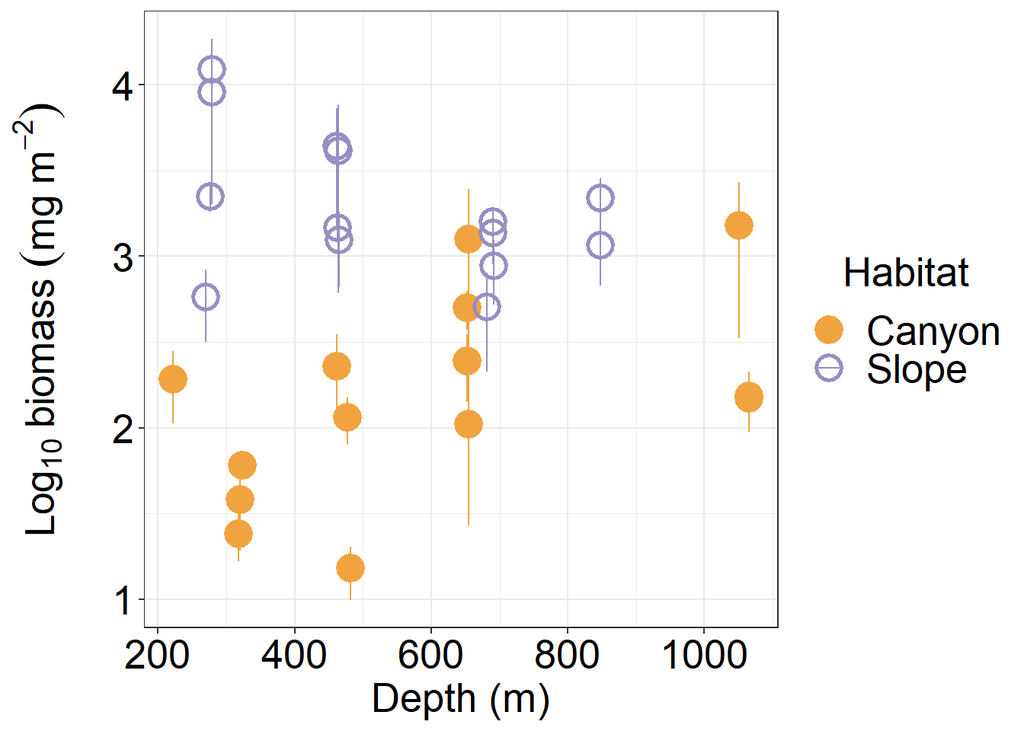

```r
(f3b <- ggplot(data=out,
       aes(x=Depth, y=log10(Biomass),
           ymin=log10(Biomass-se), ymax=log10(Biomass+se),
           shape=Habitat, colour=Habitat, fill=Habitat, linetype=Habitat))+
  geom_point(size=5, stroke=1.5, position = "dodge")+
  #stat_smooth(data=subset(out, Habitat=="Canyon"), method="lm", formula=y~x, alpha=0.2)+
  geom_errorbar(linetype=1, position = "dodge")+
  scale_colour_manual(values=c("#f1a340", "#998ec3"))+
  scale_fill_manual(values=c("black","gray"))+
  scale_linetype_manual(values=c(1,2))+
  scale_shape_manual(values=c(19,1))+
  labs(x="Depth (m)", y=expression(Log[10]~biomass~(mg~m^-2)))+
  scale_y_continuous(labels=function(x)paste("  ", x))+
  theme_bw() %+replace% large #%+replace% dark
  )
```

```r
save(f3b, file="../rds/f3b.rds")
```

Marginal relationship between macrofauna biomass and water depth in the canyon.

### 2.1.2 Generalized Least Squares (GLS) modeling

Macrofauna biomass of each sample were averaged by station (i.e., average of three cores) before further statistical tests. We used Generalized Least Squares (GLS) modeling to examine the effects of habitat (canyon vs. slope), depth, and sampling time on the mean macrofauna Biomass.

#### 2.1.2.1 Main test

```r
f <- gls(log10(Biomass) ~ Habitat+Depth+Cruise+Habitat:Depth+Habitat:Cruise+Depth:Cruise, data=out, method = "REML")
kable(summary(f)$tTable)
```

|  | Value | Std.Error | t-value | p-value |
| --- | --- | --- | --- | --- |
| (Intercept) | 1.7607114 | 0.5946870 | 2.9607363 | 0.0097190 |
| HabitatSlope | 1.7809634 | 0.5431604 | 3.2788903 | 0.0050738 |
| Depth | 0.0010308 | 0.0011814 | 0.8725299 | 0.3966718 |
| CruiseOR1_1102 | -0.1060211 | 0.7850431 | -0.1350513 | 0.8943669 |
| CruiseOR1_1114 | -0.5294915 | 0.7497321 | -0.7062409 | 0.4908633 |
| CruiseOR1_1126 | -0.4507321 | 0.7892714 | -0.5710736 | 0.5764065 |
| HabitatSlope:Depth | -0.0023101 | 0.0008190 | -2.8208140 | 0.0129059 |
| HabitatSlope:CruiseOR1_1102 | 0.9026483 | 0.5479090 | 1.6474421 | 0.1202504 |
| HabitatSlope:CruiseOR1_1114 | 0.8462198 | 0.5276473 | 1.6037603 | 0.1296108 |
| HabitatSlope:CruiseOR1_1126 | 0.6557244 | 0.5531114 | 1.1855196 | 0.2542537 |
| Depth:CruiseOR1_1102 | -0.0005507 | 0.0013687 | -0.4023995 | 0.6930661 |
| Depth:CruiseOR1_1114 | 0.0006824 | 0.0013081 | 0.5216337 | 0.6095420 |
| Depth:CruiseOR1_1126 | 0.0003104 | 0.0013135 | 0.2363486 | 0.8163592 |

```r
kable(anova(f))
```

|  | numDF | F-value | p-value |
| --- | --- | --- | --- |
| (Intercept) | 1 | 919.9544187 | 0.0000000 |
| Habitat | 1 | 38.7880001 | 0.0000162 |
| Depth | 1 | 0.9458783 | 0.3461940 |
| Cruise | 3 | 0.5088036 | 0.6821767 |
| Habitat:Depth | 1 | 6.2869251 | 0.0241516 |
| Habitat:Cruise | 3 | 1.2875721 | 0.3147983 |
| Depth:Cruise | 3 | 0.4949702 | 0.6911870 |

Significant habitat effect, but there are also significant interactions between habitat and depth.

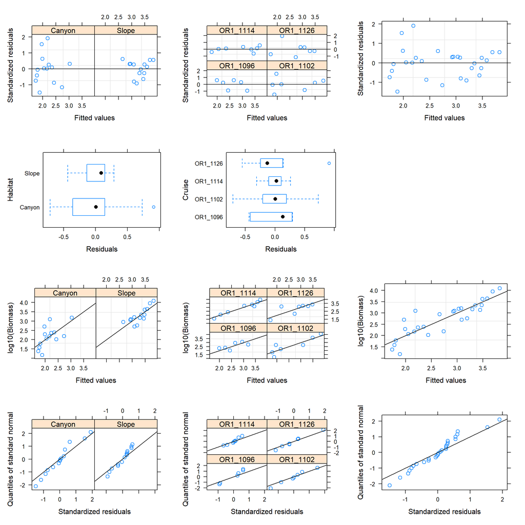

```r
# Dianotics plot
dianostic_plot(f, y = "log10(Biomass)")
```

#### 2.1.2.2 Pairwise tests

```r
# GC1 and GS1
f <- gls(log10(Biomass) ~ Habitat, data=subset(out, Station == "GC1"|Station == "GS1"), method = "REML")
kable(summary(f)$tTable)
```

|  | Value | Std.Error | t-value | p-value |
| --- | --- | --- | --- | --- |
| (Intercept) | 1.755878 | 0.2560695 | 6.857036 | 0.0004735 |
| HabitatSlope | 1.782721 | 0.3621370 | 4.922779 | 0.0026494 |

```r
kable(anova(f))
```

|  | numDF | F-value | p-value |
| --- | --- | --- | --- |
| (Intercept) | 1 | 213.74712 | 0.0000064 |
| Habitat | 1 | 24.23376 | 0.0026494 |

```r
# GC2 and GS2
f <- gls(log10(Biomass) ~ Habitat, data=subset(out, Station == "GC2"|Station == "GS2"), method = "REML")
kable(summary(f)$tTable)
```

|  | Value | Std.Error | t-value | p-value |
| --- | --- | --- | --- | --- |
| (Intercept) | 1.865593 | 0.2587591 | 7.209767 | 0.0008000 |
| HabitatSlope | 1.512820 | 0.3423062 | 4.419494 | 0.0068952 |

```r
kable(anova(f))
```

|  | numDF | F-value | p-value |
| --- | --- | --- | --- |
| (Intercept) | 1 | 259.73490 | 0.0000168 |
| Habitat | 1 | 19.53193 | 0.0068952 |

```r
# GC3 and GS3
f <- gls(log10(Biomass) ~ Habitat, data=subset(out, Station == "GC3"|Station == "GS3"), method = "REML")
kable(summary(f)$tTable)
```

|  | Value | Std.Error | t-value | p-value |
| --- | --- | --- | --- | --- |
| (Intercept) | 2.5521500 | 0.1800854 | 14.17189 | 0.0000077 |
| HabitatSlope | 0.4452811 | 0.2546792 | 1.74840 | 0.1309801 |

```r
kable(anova(f))
```

|  | numDF | F-value | p-value |
| --- | --- | --- | --- |
| (Intercept) | 1 | 474.824821 | 0.0000006 |
| Habitat | 1 | 3.056902 | 0.1309801 |

```r
# GC4 and GS4
f <- gls(log10(Biomass) ~ Habitat, data=subset(out, Station == "GC4"|Station == "GS4"), method = "REML")
kable(summary(f)$tTable)
```

|  | Value | Std.Error | t-value | p-value |
| --- | --- | --- | --- | --- |
| (Intercept) | 2.5128247 | 0.2802577 | 8.966121 | 0.0029278 |
| HabitatSlope | 0.6887116 | 0.4431264 | 1.554210 | 0.2179671 |

```r
kable(anova(f))
```

|  | numDF | F-value | p-value |
| --- | --- | --- | --- |
| (Intercept) | 1 | 164.973965 | 0.0010185 |
| Habitat | 1 | 2.415569 | 0.2179671 |

## 2.2 Per station

```r
dat.mean <- summaryBy(Biomass+Longitude+Latitude+Depth~Habitat+Station, data=out, FUN=c(mean, sd, length))
dat.mean$Biomass.se <- dat.mean$Biomass.sd/dat.mean$Biomass.length^0.5
out <- dat.mean[, c("Habitat", "Station", "Longitude.mean", "Latitude.mean", "Depth.mean", "Biomass.length", "Biomass.mean", "Biomass.sd", "Biomass.se")]
names(out) <- c("Habitat", "Station", "Longitude", "Latitude", "Depth", "n", "Biomass", "sd", "se")

out$Longitude <- round(out$Longitude, 4)
out$Latitude <- round(out$Latitude, 4)
out$Depth <- round(out$Depth, 0)
out$Biomass <- round(out$Biomass, 0)
out$sd <- round(out$sd, 1)
out$se <- round(out$se, 1)
kable(out, align="c")
```

| Habitat | Station | Longitude | Latitude | Depth | n | Biomass | sd | se |
| --- | --- | --- | --- | --- | --- | --- | --- | --- |
| Canyon | GC1 | 120.4127 | 22.4173 | 296 | 4 | 79 | 77.3 | 38.7 |
| Canyon | GC2 | 120.3365 | 22.4030 | 474 | 3 | 119 | 106.4 | 61.4 |
| Canyon | GC3 | 120.2665 | 22.3494 | 654 | 4 | 526 | 511.7 | 255.8 |
| Canyon | GC4 | 120.1927 | 22.2980 | 1060 | 3 | 606 | 788.3 | 455.1 |
| Slope | GS1 | 120.4001 | 22.2332 | 276 | 4 | 6039 | 5564.3 | 2782.1 |
| Slope | GS2 | 120.3306 | 22.2168 | 463 | 4 | 2799 | 1680.4 | 840.2 |
| Slope | GS3 | 120.3000 | 22.1833 | 688 | 4 | 1088 | 488.3 | 244.1 |
| Slope | GS4 | 120.2299 | 22.1400 | 848 | 2 | 1670 | 720.9 | 509.7 |

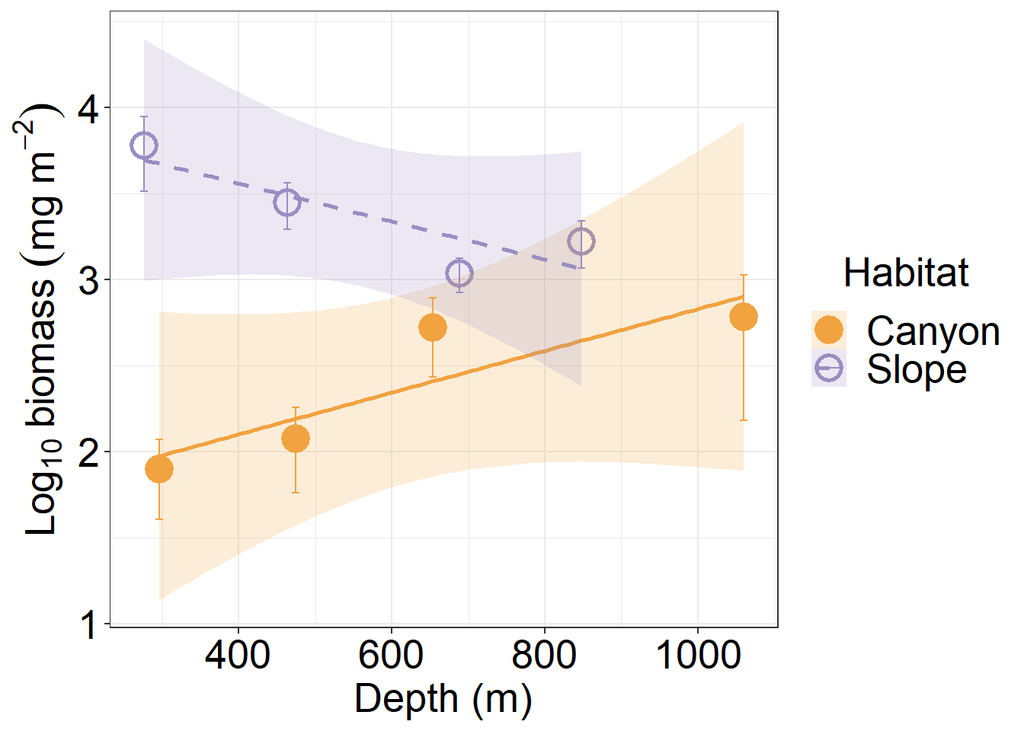

```r
ggplot(data=out,
       aes(x=Depth, y=log10(Biomass),
           ymin=log10(Biomass-se), ymax=log10(Biomass+se),
           shape=Habitat, colour=Habitat, fill=Habitat, linetype=Habitat))+
  geom_point(size=5, stroke=1.5, position = "dodge")+
  stat_smooth(method="lm", formula=y~x, alpha=0.2)+
  scale_colour_manual(values=c("#f1a340", "#998ec3"))+
  scale_fill_manual(values=c("#f1a340", "#998ec3"))+
  scale_shape_manual(values=c(19,1))+
  geom_errorbar(linetype=1, position = "dodge")+
  scale_linetype_manual(values=c(1,2))+
  labs(x="Depth (m)", y=expression(Log[10]~biomass~(mg~m^-2)))+
  theme_bw() %+replace% large #%+replace% dark
```